# Datenvisualisierung mit R

R Skripte und erste Grafiken

Armin Schäfer

schaefer@politik.uni-mainz.de

24.04.2025

## Was wir heute vorhaben

1. Vorarbeiten
2. R libraries
3. Mit Skripten arbeiten
4. Datensätze inspizieren
5. Ein Balkendiagramm erstellen

## Eine passende Ordnerstruktur anlegen

An besten ist es, wenn Sie einen Ordner für dieses Seminar in OneDrive anlegen. Sie können es aber auch lokal auf einem USB-Stick speichern. Ich schlage vor, Sie nennen den Ordner datavis. Innerhalb dieses Ordners sollten sie folgende Unterordner anlegen:

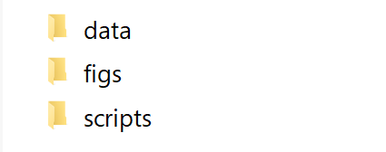

## Ein Projekt anlegen

Zu Beginn ist es sinnvoll, ein Projekt anzulegen. Dieses Projekt sollte im Ordner “datavis” gespeichert werden, weil wir dann *relative Pfade* verwenden können. Dies macht es leichter, an verschiedenen Rechnern zu arbeiten oder mit anderen zusammenzuarbeiten.<sup>1</sup>

**Tip**

Gewöhnen Sie sich an, keine *absoluten Dateipfade* zu verwenden. Wenn Ihr Skript darauf aufbaut, bekommen Sie Probleme, wenn Sie den Arbeitsplatz wechseln. Plötzlich findet R die Datensätze nicht mehr, weil sich bspw. der Laufwerksbuchstabe geändert hat.

[^1]: Der Vorteil relativer Pfade wird noch klar werden.

## Ein Projekt anlegen

[figure not shown]

[figure not shown]

## Ein Projekt anlegen

[figure not shown]

[figure not shown]

# R libraries (packages)

## Bibliotheken

In R sind viele Funktionen nicht vorinstalliert, sondern in bestimmten Bibliotheken (`packages`) enthalten. Diese Bibliotheken müssen zunächst (einmal) installiert und dann aufgerufen werden. Das wichtigste Paket, um loszulegen, nennt sich `tidyverse`. Der Befehl zum Installieren von Bibliotheken lautet `install.packages`.

```r
install.packages("tidyverse") # noch nicht eingeben!
```

Um das Paket nutzen zu können, müssen wir es nach jedem Neustart von R aktivieren. Das geschieht durch den Befehl `library()`.

```r
library(tidyverse) # hier benötigen wir keine Anführungszeichen.
```

## Getting started

Falls Sie mehrere Pakete in einem Schritt installieren wollen, geht das auch, indem sie erneut `c` nutzen.

```r
install.packages(c("tidyverse", "here"))
```

Aktiviert werden die `packages` aber einzeln.

```r
library(here)
library(tidyverse)
```

## Dasselbe – nur anders

In R gibt es fast immer mehrere Wege, etwas zu tun. Das ist anfangs verwirrend, aber bald gewöhnen Sie sich daran. Ein Beispiel: Wir können die Bibliotheken, die wir installieren wollen, auch zunächst in einen Vektor packen und dann installieren.

```r
my_packages <- c("tidyverse", "here")
install.packages(my_packages)
```

# Skripte

## Skripte

R und [Quarto](https://quarto.org/) bieten sehr gute Möglichkeiten, Text und Code zu kombinieren. Das hilft Ihnen, Dokumente zu erstellen, die auch in Zukunft nachvollziehbar sein werden.

**Wichtig!**

Wir werden immer mit Skripten arbeiten, damit Sie selbst und andere später nachvollziehen können, was Sie getan haben. Reproduzierbarkeit wird immer wichtiger in den Sozialwissenschaften. Gewöhnen Sie sich eine nachvollziehbare Arbeitsweise an und kommentieren Sie Ihren Code – oder lassen Sie ihn durch ChatGPT oder Copilot annotieren!

Zum Weiterlesen: [How to improve your relationship with your future self](https://www.scielo.cl/pdf/revcipol/v36n3/art11.pdf).

## Skripte anlegen und wiederverwenden

[figure not shown]

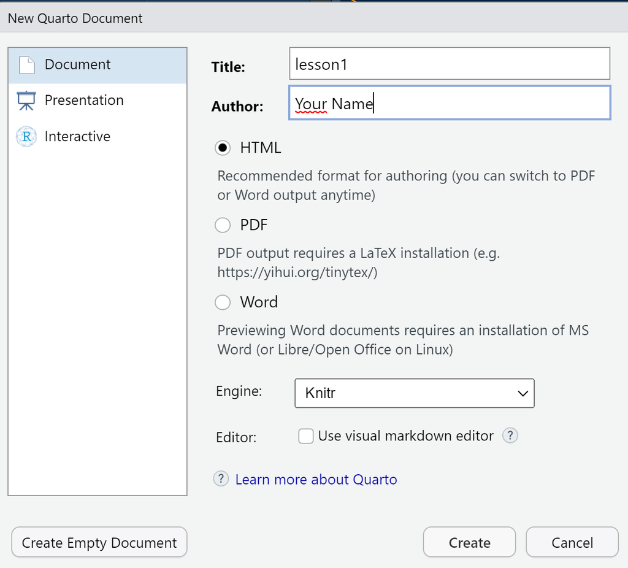

## Quarto Startseite

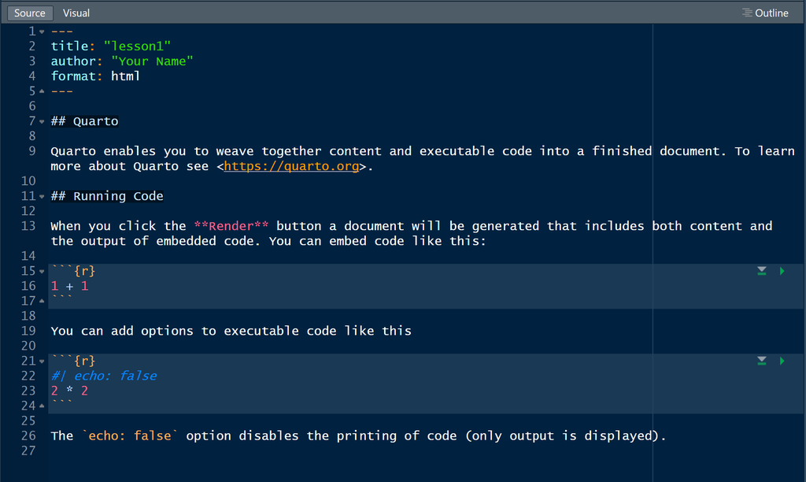

## Quarto Startseite

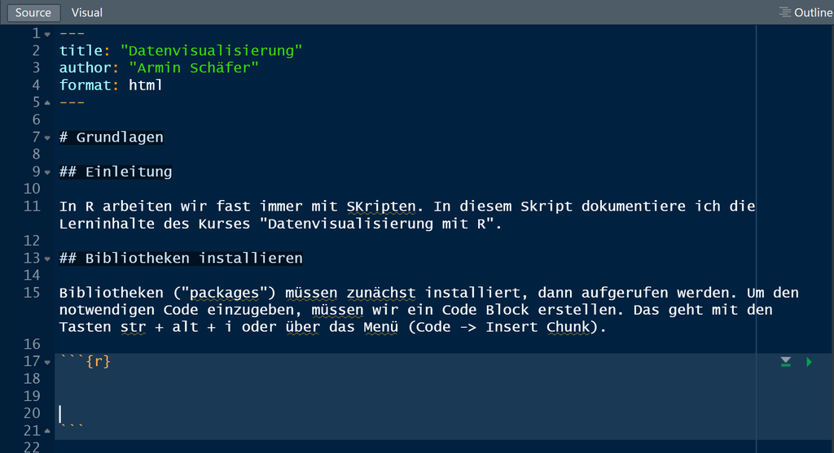

Tragen Sie die Infos (oder ähnliche) ein und speichern Sie dann das Dokument in Ihrem vorhin erstellten Ordner “scripts”.

## Pakete in Skripten laden

**Tipp**

Wenn wir immer wieder mit einem Skript arbeiten, möchten wir nicht, dass bereits installierte Bibliotheken bei jeder Aktualisierung neu installiert werden müssen. Das kann lange dauern, wenn viele notwendig sind.

In Skripten empfehle ich deshalb, stattdessen `pacman` zu nutzen. Es installiert Bibliotheken, falls diese nicht vorhanden sind, und öffnet bereits vorhandene. Der Befehl dafür ist `p_load()`, aber wir müssen zunächst `pacman` installieren.

## Pacman

```r
# Überprüfen, ob das Paket "pacman" installiert ist
if (!require("pacman")) {
    # Wenn "pacman" nicht installiert ist, installiere es
    install.packages("pacman")
    # Lade das "pacman"-Paket in die aktuelle R-Sitzung
    library(pacman)
}

# Verwende die Funktion p_load aus dem "pacman"-Paket, um mehrere Pakete zu laden
p_load(here, tidyverse)
```

Zunächst wird durch `!require()` geprüft, ob `pacman` *nicht vorhanden* ist. Falls dies der Fall ist, wird es installiert, dann geöffnet.

Nun steht der Befehl `p_load()` zur Verfügung. Der Code sieht kompliziert aus, macht uns aber das Leben leichter.

## Vom Skript zum Dokument

Nach Abspeichern des Dokuments können Sie nun oben auf den Button Render drücken. Nun wird ein html-Dokument erstellt, das sowohl Text als auch Code und (später) Output enthält.

## YAML – die Präambel

Der obere Teil des Skripts, der durch `---` umgeben ist, enthält Informationen zu Gestaltung des Dokuments. Hier lassen sich etliche Einstellung vornehmen, die dann angewendet werden.

`toc: true` Soll ein table of contents erscheinen?

`number-sections: true` Sollen die Unterabschnitte automatisch numeriert werden?

Unteroptionen werden in einer neuen Zeile und eingerückt eingetragen.

## YAML ändern

Probieren Sie nun aus, was die unten angezeigten Veränderungen in der YAML bewirken, wenn Sie das html-Dokument mit Render erneut erstellen.

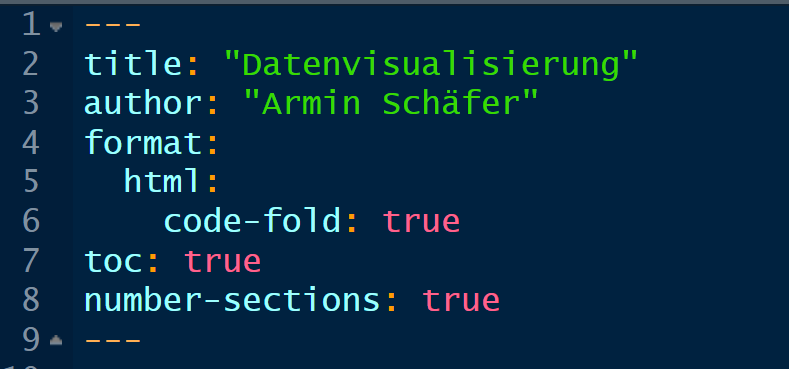

## YAML ändern – Exportierbarkeit

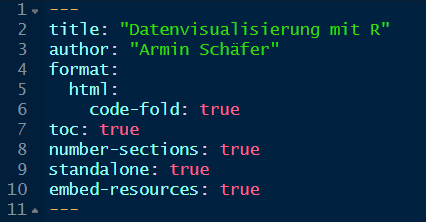

Fügen Sie die unteren beiden Zeilen in die YAML ein und drücken Sie erneut Render.

## Text (nicht in Code-Blöcken)

Außerhalb von Code-Blöcken können Sie Texte schreiben und [formatieren](https://quarto.org/docs/authoring/markdown-basics.html). Folgende Möglichkeiten gibt es:

# Erste Gliederungsebene, ## zweite Gliederungsebene usw.,

Probieren Sie dies in Ihrem Skript aus und drücken Sie erneut Render.

## Text formatieren

Probieren Sie dies in Ihrem Skript aus und drücken Sie erneut Render.

## Code-Blöcke

Code-Blöcke fügen Sie über die Tastenkombination `strg + alt + i` ein.<sup>1</sup>

1. Sie können den Code-Block ausführen, in dem Sie den kleinen Pfeil in der oberen rechten Ecke des Blocks drücken.
2. Sie können das Dokument “rendern”, dann wird der Code auch ausgeführt.
3. Zusätzlich können Sie weiterhin in der Console arbeiten. Geben Sie dort nun bitte den Befehl `here()` ein. Sie müssten nun den Dateipfad zum Ordner datavis angezeigt bekommen, in dem Sie vorhin das Projekt angelegt haben.
[^3]: Der erste Code-Block, direkt unterhalb der YAML, sollte die Befehle enthalten, mit denen Sie die Bibliotheken laden.

## Code-Blöcke in einem Skript ausführen

Wenn Sie nach rechts weisenden Pfeil am Button Run drücken, können Sie einzelne oder alle Code-Blöcke aktivieren.

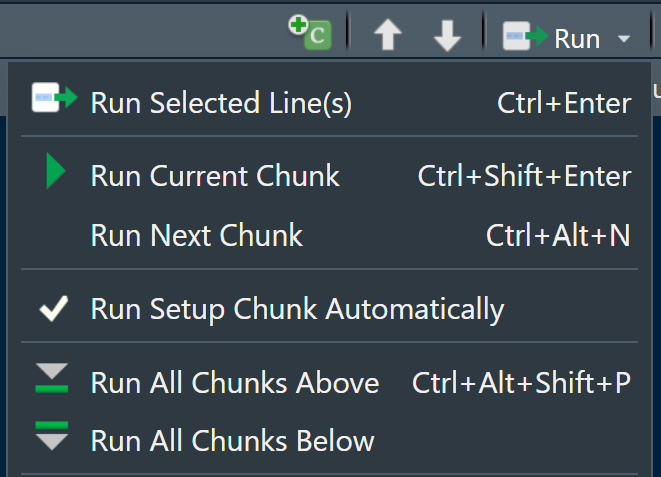

## Das Skript für diesen Kurs

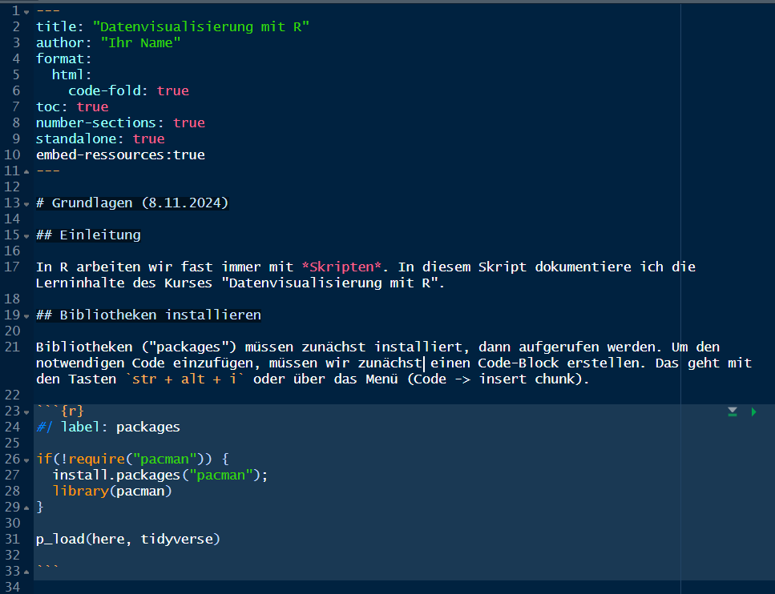

# Daten

## Daten erstellen

In der Zukunft arbeiten wir mit realen Daten. Heute simulieren wir Daten, um damit erste Übungen durchführen zu können. Dazu erstellen wir einen einfachen Datensatz, genannt [tibble](https://tibble.tidyverse.org/). Wir generieren ein Parlament, das 300 Sitze hat und in dem fünf Parteien verteten sind. Wie viele Sitze eine Partei hat, wird zufällig bestimmt.<sup>1</sup>

```r
bt <-
  tibble(
    "Sitze" = 1:300,
    "Partei" = sample(
      x = c("Linke", "SPD", "Grüne", "FDP", "CDU"),
      size = 300,
      replace = TRUE
    )
  )
```

[^4]: Dies geschieht über den Befehl `sample`, der aber im Moment nicht so wichtig für uns ist.

## Mit einem Datensatz arbeiten

Tippen Sie nun `bt` in der Konsole ein und drücken Sie Enter. Sie bekommen einen Teil des Datensatzes angezeigt.

Um den gesamten Datensatz zu sehen, verwenden wir `view()`. Dieser Befehl öffnet ein Fenster, in dem er zu sehen ist. Vergleichen Sie Ihre Zahlen mit denen der Nachbar:in. Warum unterscheiden sie sich?

```r
view(bt)
```

## Mit einem Datensatz arbeiten

Da `view()` manchmal umständlich ist, können wir auch `head()` verwenden, dann werden nur die ersten Zeilen angezeigt.<sup>1</sup>

```r
head(bt)
```

```
# A tibble: 6 × 2
  Sitze Partei
  <int> <chr>
1     1 Linke
2     2 FDP
3     3 Linke
4     4 Linke
5     5 Linke
6     6 Linke
```

[^5]: `view()` und `head()` sind Befehle, die Sie typischerweise nicht im Skript festhalten, sondern in die Konsole eingeben.

## Mit einem Datensatz arbeiten

Eine andere Möglichkeit besteht darin, den Befehl `glimpse()` zu verwenden, der u.a. Informationen zur Anzahl der Zeilen und Spalten anzeigt.

```r
glimpse(bt)
```

```
Rows: 300
Columns: 2
$ Sitze  <int> 1, 2, 3, 4, 5, 6, 7, 8, 9, 10, 11, 12, 13, 14, 15, 16, 17, 18, …
$ Partei <chr> "Linke", "FDP", "Linke", "Linke", "Linke", "Linke", "Linke", "S…
```

## Mit einem Datensatz arbeiten

Um auf eine spezifische Variable (= Vektor, = Spalte) zuzugreifen, müssen wir erst den Datensatz nennen und den Variablennamen mit Hilfe eines `$` verbinden. Zum Beispiel können wir uns die Ausprägungen von “Partei” mit dem Befehl `table()` in einer Tabelle ausgeben lassen.

```r
table(bt$Partei)
```

```
  CDU   FDP Grüne Linke   SPD
   56    53    53    79    59
```

## Mit einem Datensatz arbeiten

Um die Prozentwerte zu erhalten, verwenden wir den Befehl `prop.table()`.

```r
t <- table(bt$Partei) # wir speichern die Tabelle in einem Vektor t.
prop.table(t) # diesen Vektor wandelt prop.table in Anteile um.
```

```
      CDU       FDP     Grüne     Linke       SPD
0.1866667 0.1766667 0.1766667 0.2633333 0.1966667
```

## Umwandeln

Mit dem Befehl `round()` können wir bestimmen, wie viele Nachkommastellen angezeigt werden. In diesem Fall zwei.

```r
t2 <- prop.table(t)
round(t2, 2)
```

```
  CDU   FDP Grüne Linke   SPD
 0.19  0.18  0.18  0.26  0.20
```

Dies lässt sich auch in einem Schritt bewältigen, ist aber u.U. weniger übersichtlich.

```r
round(prop.table(t), 2)
```

```
  CDU   FDP Grüne Linke   SPD
 0.19  0.18  0.18  0.26  0.20
```

## Übung

Erstellen Sie nun einen Vektor mit dem Namen `p`, in dem die Anteile als `P`rozentwerte (zwischen 0 und 100) enthalten sind. Bitte geben Sie nur eine Nachkommastelle an.

## Prozentwerte

```r
t2 <- prop.table(t)
t2 <- round(t2, 3) # Vosicht! t2 wird überschrieben.
p <- 100*t2

head(p)
```

```
  CDU   FDP Grüne Linke   SPD
 18.7  17.7  17.7  26.3  19.7
```

## Ausblick

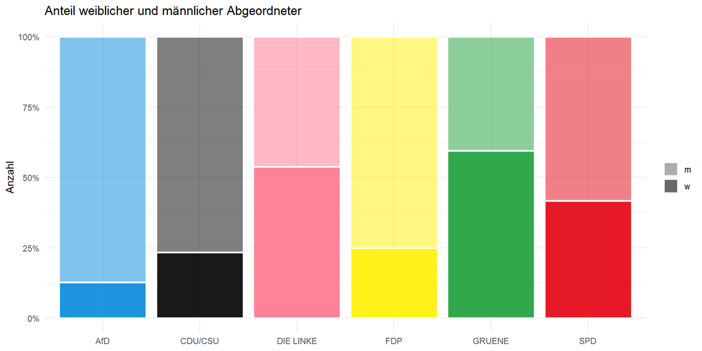

Datenvisualisierung